# Week 5 Homework

Shawn Wang

2026-02-11

# Jamie cleaning genie

```r
jamie_genie <- function(dat, wordcol, omit_stops = TRUE, lemmatize = TRUE) {
  # Input validation
  if (!wordcol %in% names(dat)) {
    stop(paste("Column", wordcol, "not found in dataframe"))
  }

#load stopword and replacement lists from github
load(url("https://github.com/Reilly-ConceptsCognitionLab/reillylab_publicdata/blob/main/Temple_stops25.rda?raw=true"))
load(url("https://github.com/Reilly-ConceptsCognitionLab/reillylab_publicdata/blob/main/replacements_25.rda?raw=true"))


 # Create working copy and perform initial split
  dat_prep <- dat %>%
    dplyr::mutate(
      id_row_orig = factor(seq_len(nrow(dat))),
      text_initialsplit = tryCatch(
        stringi::stri_enc_toutf8(as.character(.[[wordcol]]),
                                 is_unknown_8bit = TRUE,
                                 validate = TRUE),
        error = function(e) stringi::stri_encode(as.character(.[[wordcol]]), to = "UTF-8")
      ) %>%
        tolower()
    )

  # Standardize apostrophes in original text
  dat_prep <- dat_prep %>%
    dplyr::mutate(
      text_initialsplit = ifelse(
        is.na(text_initialsplit),
        NA_character_,
        stringi::stri_replace_all_regex(
          text_initialsplit,
          "[\u2018\u2019\u02BC\u201B\uFF07\u0092\u0091\u0060\u00B4\u2032\u2035]",
          "'"
        )
      )
    )

  # Perform initial split into words (retains contractions)
  dat_prep <- dat_prep %>%
    tidyr::separate_rows(text_initialsplit, sep = "[[:space:]]+") %>%
    dplyr::mutate(
      text_initialsplit = ifelse(
        is.na(text_initialsplit) | stringi::stri_isempty(text_initialsplit),
        NA_character_,
        text_initialsplit
      )
    ) %>%
    # Remove original column
    dplyr::select(-all_of(wordcol))

  # Initialize cleaning column with actual cleaned text
  dat_prep <- dat_prep %>%
    dplyr::mutate(
      word_clean = text_initialsplit,
      # Remove non-alphabetic characters except apostrophes
      word_clean = ifelse(
        is.na(word_clean),
        NA_character_,
        stringi::stri_replace_all_regex(word_clean, "[^a-zA-Z']", " ")
      ),
      # Squish whitespace
      word_clean = ifelse(
        is.na(word_clean),
        NA_character_,
        stringr::str_squish(word_clean)
      ),
      word_clean = ifelse(
        is.na(word_clean),
        NA_character_,
        stringi::stri_replace_all_regex(word_clean, "[^a-z']", "")
      ),
      word_clean = ifelse(
        is.na(word_clean),
        NA_character_,
        stringi::stri_replace_all_regex(word_clean, "[^[:alnum:]']", "")
      )
    )

  # Apply contractions replacement (only for non-NA values)
  dat_prep <- replacements_25(dat = dat_prep, wordcol = word_clean)

  # Perform additional splitting after replacements (keeping NAs)
  dat_prep <- dat_prep %>%
    tidyr::separate_rows(word_clean, sep = "[[:space:]]+", convert = TRUE) %>%
    dplyr::mutate(
      word_clean = ifelse(
        is.na(word_clean) | stringi::stri_isempty(word_clean),
        NA_character_,
        word_clean
      ),
      id_row_postsplit = seq_len(dplyr::n())  # Fixed this line
    )

  # Lemmatization if requested (only for non-NA values)
  if (lemmatize) {
    dat_prep <- dat_prep %>%
      dplyr::mutate(
        word_clean = ifelse(
          is.na(word_clean),
          NA_character_,
          textstem::lemmatize_strings(word_clean)
        )
      )
  }

  # Stopword removal if requested (now keeps NAs)
  if (omit_stops) {
    stopwords <- tolower(Temple_stops25$word)
    dat_prep <- dat_prep %>%
      dplyr::mutate(
        is_stopword = ifelse(
          is.na(word_clean),
          NA,
          word_clean %in% stopwords
        ),
        word_clean = ifelse(is_stopword, NA_character_, word_clean)
      ) %>%
      dplyr::select(-is_stopword)  # Remove the is_stopword column
  }

  return(dat_prep)
}
```

# Shawn Cleaning Genie (and related functions)

```r
keep_alphab <- function(x) {

  #uses regex to remove any numbers from a string
  x_clean <- x %>%
    mutate(string = gsub(pattern = "[^a-zA-Z]", replacement = " ", string))



  return(x_clean)

}


#takes a string returns a data frame
split_string <- function(x) {

  #convert to a data frame first
  cleaned_x <- data.frame(string = x) %>%
    separate_longer_delim(string, delim = " ") %>% #pivots to long format based on delimeter of space
    filter(string != "") #filters so that empty rows are deleted
  return(cleaned_x)

}


#x is a character object (string), NOT a data frame
shawn_genie <- function(x) {


  #start as character object
  x <- tolower(x) #convert to lowercase
  x <- stripWhitespace(x) #strip whitespace
  x <- stri_remove_empty(x) #removes empty strings
  x <- gsub("\\b[a-zA-Z]\\b{1}", " ", x) # omits singletons including Aa and Ii
  x <- split_string(x) #pivots to one word per row


  load(url("https://github.com/Reilly-ConceptsCognitionLab/reillylab_publicdata/blob/main/replacements_25.rda?raw=true"))

  #load in the list of contractions that we want to replace
  contractions_list <- replacements_25$word


  x <- x %>%
    mutate(new_words = case_when( #create new variable called new_words that will have the replaced words
      is.na(string) ~ NA, #if empty then do nothing
      string %in% contractions_list ~ replacements_25$replacement[match(string, replacements_25$word)], #if word is a contraction, replace it with the expanded version
      TRUE ~ string), #if it's none of those options, just keep the original
      check = ifelse(is.na(string), NA, string %in% contractions_list), #this is for debugging
      string = new_words #reassign to the string name
    ) %>%
    select(string) #delete the intermediate variables
  x <- keep_alphab(x) #remove all special characters

  x$string <- lemmatize_strings(x$string) #lemmatize the words, remove affixes etc


  load(url("https://github.com/Reilly-ConceptsCognitionLab/reillylab_publicdata/blob/main/Temple_stops25.rda?raw=true"))

  #load in list of stopwords to remove
  stopwords <- tolower(Temple_stops25$word)
  x <- x %>%
    mutate(
      is_stopword = ifelse( #create new variable identifying which words are stopwords
        is.na(string), NA, #if empty do nothing
        string %in% stopwords) #if not empty then TRUE if stopword, FALSE if not stopword
      ) %>%
    filter(is_stopword == FALSE) %>% #keep only the words that are NOT stopwords
    select(string) #delete intermediate variables


  x$string <- gsub(x = x$string, pattern = "\\d+", replacement = " ") #remove numbers



  x <- split_string(x) #this last step removes all other whitespace and just cleans up in general

  return(x)

}
```

Homework:

- Clean up CSS and make it a professional format
- Run cleaning genie on unabomber
- Merge with lookup
- Pick 5 indices and merge
- Generate descriptive statistics
- Generate some plots of these sentiments

# Load in text, run cleaning genie

We’re going to start by reading in the data from GitHub and then running our custom cleaning genie that will get the data frame into a format ready for analysis, with one lemmatized word per row.

```r
#load in text as a single character vector
unabomb_raw <- paste(readLines('https://raw.githubusercontent.com/Reilly-ConceptsCognitionLab/reillylab_publicdata/main/unabomber_manifesto.txt'))


#run the cleaning genie
unabomb_clean <- shawn_genie(unabomb_raw)
```

# Merge with lookup

In order to enable analysis of sentiment within the unabomber manifesto, I’m doing to merge it with a database of word/sentiment associations. Then, I’m going to select 5 sentiment variables that I’m interested in analyzing within the manifesto: arousal, intensity, trust, valence, and age of acquisition as a proxy of lexical complexity.

```r
#load in database from online
load(url("https://github.com/Reilly-ConceptsCognitionLab/reillylab_publicdata/blob/main/lookup_Jul25.rda?raw=true"))

#cut the database to the variables that we're interested in
lookup_small <- lookup_Jul25 %>% select(word, emo_arousal_b24, emo_intensity, emo_trust, emo_valence_b24, lex_AoA)

df_prep <- unabomb_clean %>% left_join(lookup_small, by = c("string" = "word"))
```

# Descriptive Statistics

We can generate some descriptive statistics by using describe() from the psych package.

```r
df_prep %>%
  select(-string) %>%
  psych::describe() %>%
  select(mean, sd, median)
```

|  | mean | sd | median |
| --- | --- | --- | --- |
| emo_arousal_b24 | 2.76 | 1.74 | 2.32 |
| emo_intensity | 0.56 | 0.78 | 0.10 |
| emo_trust | 0.07 | 0.12 | 0.07 |
| emo_valence_b24 | 5.23 | 1.21 | 5.01 |
| lex_AoA | 7.22 | 2.69 | 6.89 |

# Some plots

Similarly, and perhaps more helpfully, we can display these data visually:

## Histogram of emotional arousal

Here we can see that most of the words are relatively low in arousal (blue) but there text skews positively towards some high arousal words (red).

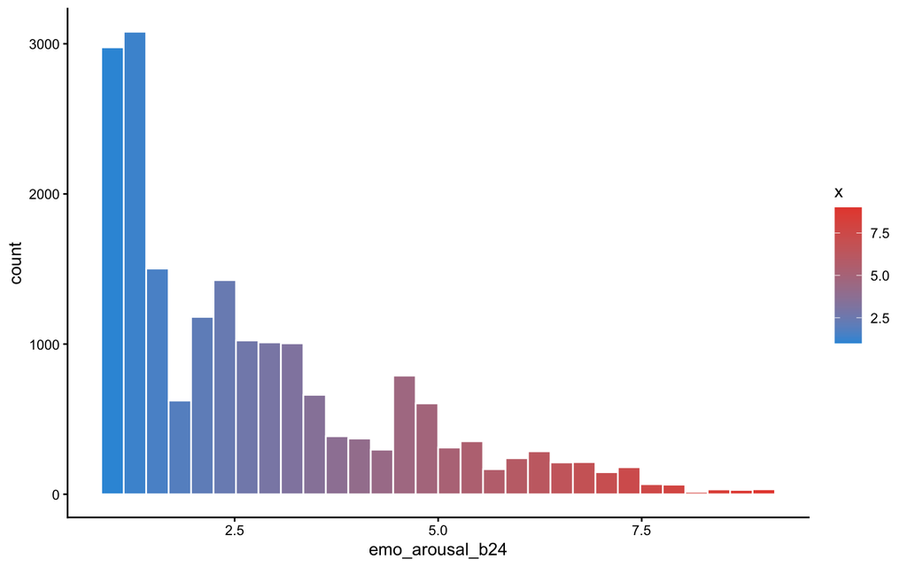

```r
df_prep %>%
  ggplot(aes(x = emo_arousal_b24, fill = after_stat(x))) +
  geom_histogram(color = "white") +
  scale_fill_gradient(low = "#3498db", high = "#e74c3c") +
  theme_classic()
```

## Intensity ratings across the corpus

We can see from this figure that the manifesto keeps up a generally consistent intensity over the length of the document.

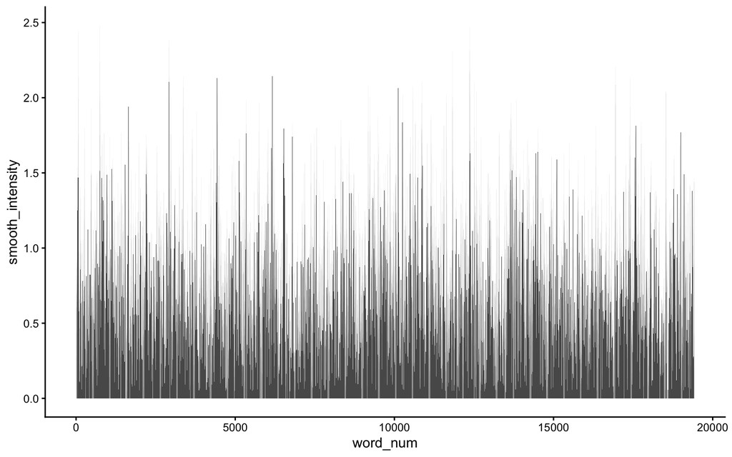

```r
df_prep %>% mutate(smooth_intensity = zoo::rollmean(emo_intensity, k = 5, fill = NA),
                             word_num = row_number()) %>%
  ggplot(mapping = aes(x = word_num, y = smooth_intensity)) +
  geom_col(position = "dodge") +
  theme_classic()
```

## Correlation plot across all 5 variables

We can take a look at how these variables are related to each other through a heatmap:

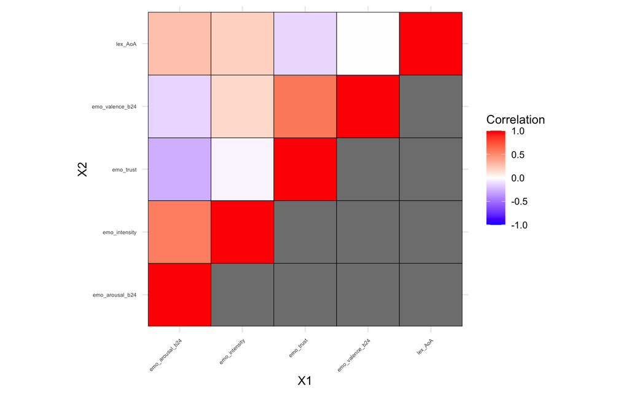

```r
cor_df <- df_prep %>%
  select(-string)

get_upper_tri <- function(cormat){
    cormat[lower.tri(cormat)]<- NA
    return(cormat)
}

cormat <- rcorr(as.matrix(cor_df))
cormat_r <- cormat$r
cormat_r_upper <- get_upper_tri(cormat_r)
cormat_r_melt <- melt(cormat_r_upper, na.rm = TRUE)
names(cormat_r_melt)[3] <- "correlation"


cormat_r_melt %>%
  ggplot(mapping = aes(x = X1, y = X2, fill = correlation)) +
  geom_tile(color = "black") +
  scale_fill_gradient2(low = "blue", high = "red", mid = "white",
   midpoint = 0, limit = c(-1, 1), space = "Lab",
   name="Correlation") +
  theme_minimal() +
  theme(axis.text.x = element_text(angle = 45, vjust = 1,
    size = 5, hjust = 1),
    axis.text.y = element_text(size = 5))+
 coord_fixed()
```

From our correlation heatmap we can see that trust and valence seem to be generally negatively correlated with arousal, whereas intensity and age of acquisition seem to be positively correlated with arousal. Valence and trust also appear to be positively correlated.

# Line graphs

Finally, we can track the levels of lexical complexity as measured by age of acquisition through some longitudinal line graphs:

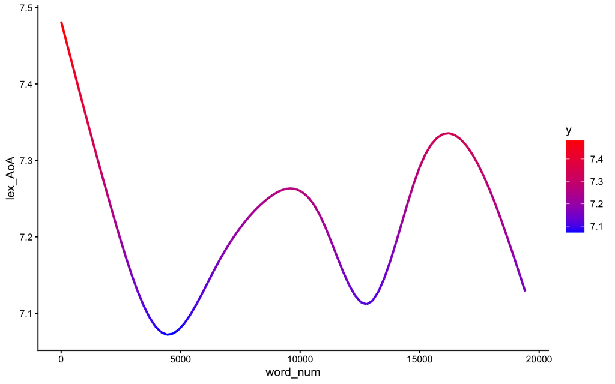

```r
df_prep %>%
  mutate(word_num = row_number()) %>%
  ggplot(mapping = aes(x = word_num, y = lex_AoA)) +
  geom_smooth(se = FALSE,
              aes(color = after_stat(y))) +
  scale_color_gradient(low = "blue", high = "red") +
  theme_classic()
```

What we might glean from this graph is that the manifesto begins with words of high lexical complexity which quickly decreases, but has two other peaks throughout the manifesto. Of note, the range of the lexical complexity is around 7.0 to 7.5, meaning the manifesto as a whole maintains a high level of lexical complexity throughout, and these fluctuations are relatively minor when considering the level of the document as a whole.